# Reproducible Research- Project 1

Carlos Martinez

26/8/2020

## 1. Preparation, loading and preprocessing the data

### a). Load the data

```r
data<-read.csv("activity.csv")
head(data)
```

```
##   steps       date interval
## 1    NA 2012-10-01        0
## 2    NA 2012-10-01        5
## 3    NA 2012-10-01       10
## 4    NA 2012-10-01       15
## 5    NA 2012-10-01       20
## 6    NA 2012-10-01       25
```

```r
# Note: there are NA values in the steps variable
```

### b). Process/transform the data (if necessary) into a format suitable for your analysis

```r
dev_null <- Sys.setlocale("LC_TIME", "english")
initdata <- read.csv("activity.csv", colClasses=c("numeric", "Date", "numeric"))
```

```r
data <- data[!(is.na(data$steps)), ]
```

```r
# We will use the aggregate () function.
totalstep <- aggregate(steps ~ date, data, sum)
head(totalstep)
```

```
##         date steps
## 1 2012-10-02   126
## 2 2012-10-03 11352
## 3 2012-10-04 12116
## 4 2012-10-05 13294
## 5 2012-10-06 15420
## 6 2012-10-07 11015
```

```r
# Note: there is not NA values in the steps variable
```

### 1.1 Make a histogram of the total number of steps taken each day

```r
totalstep <- with(data, aggregate(steps, by = list(date), FUN = sum, na.rm = TRUE))
head(totalstep)
```

```
##      Group.1     x
## 1 2012-10-02   126
## 2 2012-10-03 11352
## 3 2012-10-04 12116
## 4 2012-10-05 13294
## 5 2012-10-06 15420
## 6 2012-10-07 11015
```

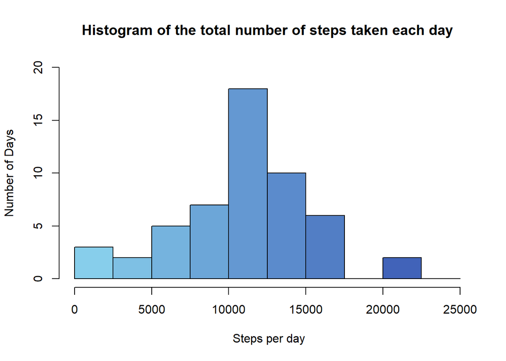

```r
names(totalstep) <- c("date", "steps")
color <- colorRampPalette(c("skyblue", "darkblue", "skyblue"))
hist(totalstep$steps, xlab=" Steps per day", ylab=" Number of Days ", main=" Histogram of the total number of steps taken each day ", col = color(32), ylim = c(0,20), breaks = seq(0,25000, by=2500))
```

### 1.2. Calculate and report the mean and median total number of steps taken per day

```r
library(dplyr)
statistics <- summarise(totalstep, mean=mean(totalstep $steps),
                               median=median(totalstep $steps))
statistics
```

```
##       mean median
## 1 10766.19  10765
```

```r
# We report the mean and median: Mean is 10766.19 and Median value 10765
```

### 2.1. Make a time series plot (i.e. type = “l”) of the 5-minute interval (x-axis) and the average number of steps taken, averaged across all days (y-axis)

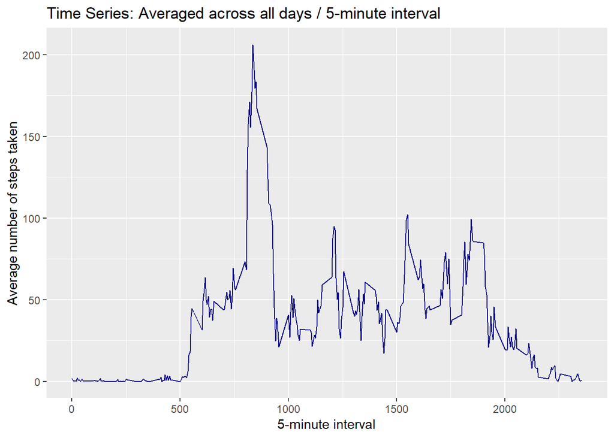

```r
library(ggplot2)
prom<- aggregate(x=list(steps=data$steps), by=list(interval=data$interval),
                      FUN=mean, na.rm=TRUE)
ggplot(data=prom, aes(x=interval, y=steps)) +
    geom_path(colour = " darkblue", lwd=0.5)+
    ggtitle("Time Series: Averaged across all days / 5-minute interval")+
    xlab("5-minute interval") +
    ylab("Average number of steps taken")
```

### 2.2 Which 5-minute interval, on average across all the days in the dataset, contains the maximum number of steps?

```r
prom[which.max(prom[,2]),1]
```

```
## [1] 835
```

```r
#Maximum number of steps is the interval 835
```

```r
prom[which.max(prom[,2]),1]
```

```
## [1] 835
```

```r
#Maximum number of steps is the interval 835
```

### 3.1. Calculate and report the total number of missing values in the dataset (i.e. the total number of rows with NAs)

```r
datos<-read.csv("activity.csv")
colSums(is.na(datos))
```

```
##    steps     date interval
##     2304        0        0
```

```r
# 2304 NA values contained in the steps variable, The VIM package helps us to see the proportion of NAs in the steps variable.
```

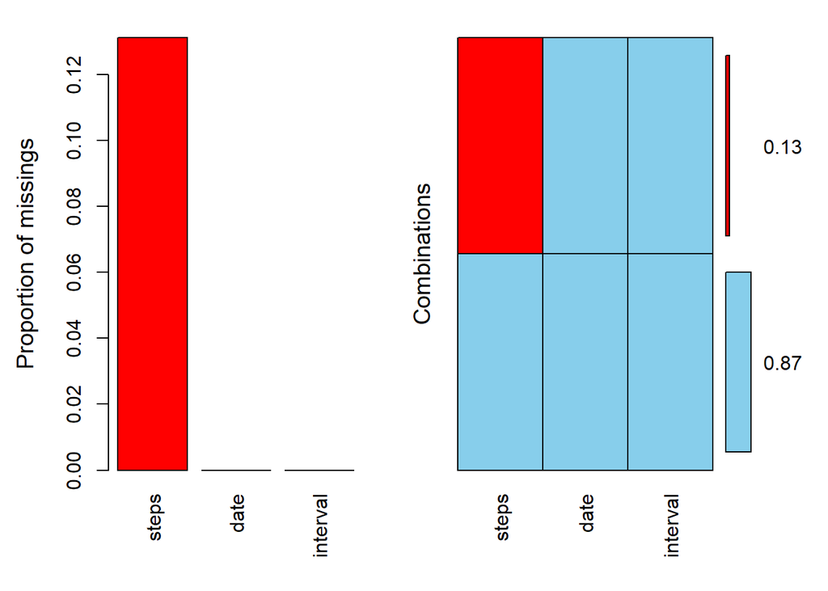

```
##
##  Variables sorted by number of missings:
##  Variable     Count
##     steps 0.1311475
##      date 0.0000000
##  interval 0.0000000
```

```r
library(VIM)
library(mice)
aggr(datos,numbers=T,sortVar=T)
```

```r
# 13.11% of data in the steps variable are NAs
```

### 3.2 Devise a strategy for filling in all of the missing values in the dataset. The strategy does not need to be sophisticated. For example, you could use the mean/median for that day, or the mean for that 5-minute interval, etc.

```r
# Imputation with the mean (37.3826) across all days, we use the package MICE
datos<-data.frame(datos)
columns <- c("steps","date","interval")
imputed_data <- mice(datos[,names(datos) %in% columns],m = 1, maxit = 1, method = "mean",seed = 2018,print=F)
# NOTE: we can also impute the data with the mean with the following function:
meanStepsInterval <- aggregate(steps ~ interval, data, mean)
head(meanStepsInterval)
```

```
##   interval     steps
## 1        0 1.7169811
## 2        5 0.3396226
## 3       10 0.1320755
## 4       15 0.1509434
## 5       20 0.0754717
## 6       25 2.0943396
```

```r
imputedData <- initdata
for(x in 1:17568) {
    if(is.na(imputedData[x, 1])==TRUE) {
        imputedData[x, 1] <- meanStepsInterval[meanStepsInterval$interval %in% imputedData[x, 3], 2]
    }
}
head(imputedData)
```

```
##       steps       date interval
## 1 1.7169811 2012-10-01        0
## 2 0.3396226 2012-10-01        5
## 3 0.1320755 2012-10-01       10
## 4 0.1509434 2012-10-01       15
## 5 0.0754717 2012-10-01       20
## 6 2.0943396 2012-10-01       25
```

### 3.3 Create a new dataset that is equal to the original dataset but with the missing data filled in.

```r
complete.data <- mice::complete(imputed_data)
complete<-aggregate(steps~date,complete.data,sum)
```

### 3.4 Make a histogram of the total number of steps taken each day and Calculate and report the mean and median

#### 3.4.1. Calculate the mean and median total number of steps per day after imputation

```r
statistics1 <- summarise(complete, mean=mean(complete $steps),
                               median=median(complete$steps))
statistics1
```

```
##       mean   median
## 1 10766.19 10766.19
```

#### 3.4.2. Do these values differ from the estimates from the first part of the assignment?

##### Answer: the means are equal the medians differ by 1.19

#### 3.4.3. What is the impact of imputing missing data on the estimates of the total daily number of steps?

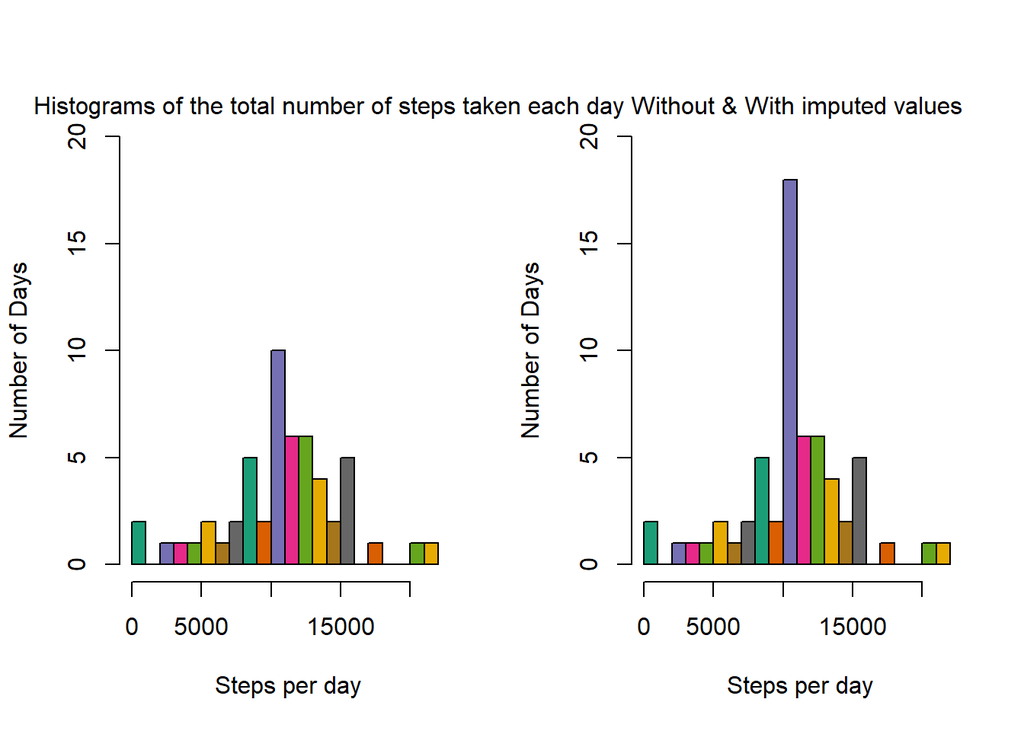

```r
library(RColorBrewer)
darkcols <- brewer.pal(8, "Dark2")
par(mfrow = c(1, 2))
hist(totalstep $steps, breaks=20, , xlab=" Steps per day", ylab=" Number of Days ",
          col = darkcols, ylim=c(0, 20), main=NULL)
hist(complete$steps, breaks=20, , xlab=" Steps per day", ylab=" Number of Days ",
               col = darkcols, ylim=c(0, 20), main=NULL)
mtext("Histograms of the total number of steps taken each day Without & With imputed values", adj=1)
```

##### Answer: Regarding the mean and median there is no considerable impact, but we can observe in the histograms that the frequency increases in the imputed data.

### 4.1. Create a new factor variable in the dataset with two levels – “weekday” and “weekend” indicating whether a given date is a weekday or weekend day.

```r
"English_United States.1252"
```

```
## [1] "English_United States.1252"
```

```r
daysData <- imputedData
daysData$days <- weekdays(daysData$date)
daysData$weekday <- as.character(rep(0, times=17568))
for(x in 1:17568) {
    if(daysData[x, 4] %in% c("Saturday", "Sunday")) {
        daysData[x, 5] <- "weekend"
    } else {
        daysData[x, 5] <- "weekday"
    }
}
daysData$weekday <- factor(daysData$weekday)
weekdayData <- daysData[daysData$weekday=="weekday", ]
weekendData <- daysData[daysData$weekday=="weekend", ]
weekdayMean <- aggregate(steps ~ interval, weekdayData, mean)
weekendMean <- aggregate(steps ~ interval, weekendData, mean)
```

### 4.2. Make a panel plot containing a time series plot

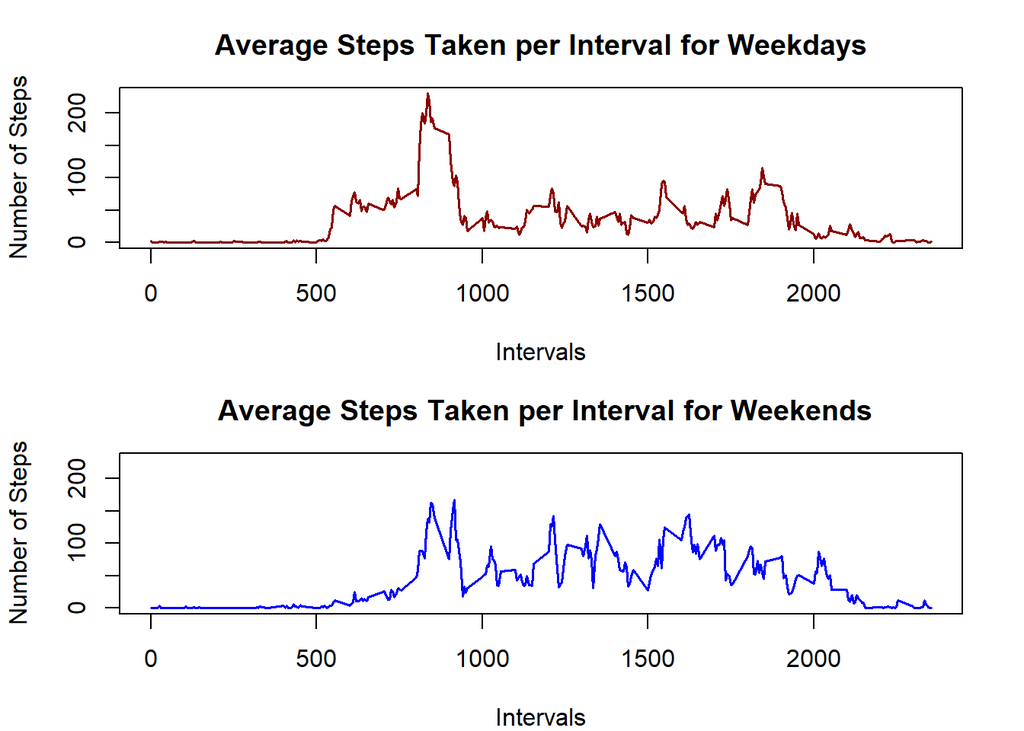

```r
par(mfrow=c(2, 1), mar=c(4, 4.1, 3, 2.1))
plot(weekdayMean$interval, weekdayMean$steps, type="l",
     main="Average Steps Taken per Interval for Weekdays",
     xlab="Intervals", ylab="Number of Steps",
     col="darkred", lwd=1.5, ylim=c(0, 230))
plot(weekendMean$interval, weekendMean$steps, type="l",
     main=" Average Steps Taken per Interval for Weekends",
     xlab="Intervals", ylab="Number of Steps",
     col="blue", lwd=1.5, ylim=c(0, 230))
```